# Tree-Based Methods

Elara

2016年5月25日

# Cross-Validation

## The Validation Set Approach

数据分成2组,一组做training set,另一组做validation set or hold-out set.用training set拟合模型,用模型预测validation set的数据,计算validation set中的真实数据与预测值的MSE.

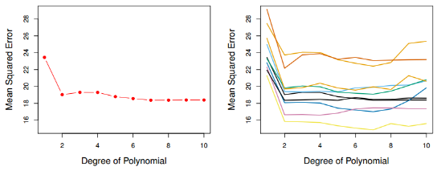

左图:只进行一次分组(随机),平方项的加入显著减低的MSE,三次方反而提高了MSE,效果不好  
右图:每条线代表一次分组(随机),不同分组结果会导致结果的显著不同,并且由于分组要减半拟合模型所用的数据,也会导致模型拟合效果不好

## K-Fold Cross-Validation

1. 把原始数据随机分成k部分,取出一部分作为validation set,剩下的k-1个部分作为training set,并求得其MSE
2. 取出第二部分作为validation set,剩下的作为training set,并求得其MSE
3. 重复k次,计算出k个MSE,取平均得到CV值

## example-只分一次

```r
library(ISLR)
attach(Auto)
#E1
set.seed(2)
#随机取出training set
train=sample(392,196)
lm.fit=lm(mpg~horsepower,subset=train)
# 1阶模型MSE
mean((mpg-predict(lm.fit,Auto))[-train]^2)
```

```
## [1] 23.29559
```

```r
# poly表示多项式,后面写入变量名和最高阶数
lm.fit2=lm(mpg~poly(horsepower,2,raw=T),data=Auto,subset=train)
# 2阶模型MSE
mean((mpg-predict(lm.fit2,Auto))[-train]^2)
```

```
## [1] 18.90124
```

```r
# 3阶模型
lm.fit3=lm(mpg~poly(horsepower,3,raw=T),data=Auto,subset=train)
# 3阶模型MSE
mean((mpg-predict(lm.fit3,Auto))[-train]^2)
```

```
## [1] 19.2574
```

```r
# 2阶结果最小
#E2(只改变seed为1)
set.seed(1)
train=sample(392,196)
lm.fit=lm(mpg~horsepower,subset=train)
mean((mpg-predict(lm.fit,Auto))[-train]^2)
```

```
## [1] 26.14142
```

```r
lm.fit2=lm(mpg~poly(horsepower,2,raw=T),data=Auto,subset=train)
mean((mpg-predict(lm.fit2,Auto))[-train]^2)
```

```
## [1] 19.82259
```

```r
lm.fit3=lm(mpg~poly(horsepower,3,raw=T),data=Auto,subset=train)
mean((mpg-predict(lm.fit3,Auto))[-train]^2)
```

```
## [1] 19.78252
```

```r
# 3阶结果最小
detach(Auto)
```

## example-k-flod

```r
library(boot)
set.seed(17)
cv.error.10=rep(0,10)
for (i in 1:10){
        #加入i次方多项式进行拟合
glm.fit=glm(mpg~poly(horsepower,i),data=Auto)
#计算加入i次方的MSE均值,分10个flod(k=10)
cv.error.10[i]=cv.glm(Auto,glm.fit,K=10)$delta[1]
}
cv.error.10
```

```
##  [1] 24.20520 19.18924 19.30662 19.33799 18.87911 19.02103 18.89609
##  [8] 19.71201 18.95140 19.50196
```

```r
# 取2次方,后面阶数太高不划算
```

# The Basics of Decision Trees

把预测空间(prediction space)用一些简单范围表示  
## 回归树 regression trees

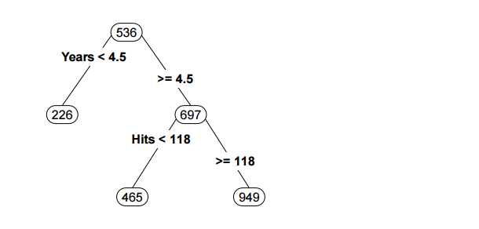

总均值536,年份小于4.5的均值226,大于4.5的分两类,hits小与118的均值465,大于等于118的949  
Years is the most important factor in determining Salary, and players with less experience earn lower salaries than more experienced players. Given that a player is less experienced, the number of hits that he made in the previous year seems to play little role in his salary. But among players who have been in the major leagues for five or more years, the number of hits made in the previous year does affect salary, and players who made more hits last year tend to have higher salaries. The regression tree shown in Figure is likely an over-simplification of the true relationship between Hits, Years, and Salary. However, it has advantages over other types of regression models: it is easier to interpret, and has a nice graphical representation.

### 回归树求法

1. 将需要分类的预测空间分成J个(R1,R2,…RJ).如不同人的工资放到years和hits平面空间中,把这个平面分成3块
2. 对每一个落入Rj中的样本,用Rj的均值作为其预测值
3. 使得$RSS= \sum _{j=1}^{J} \sum _{i\in Rj} (y_i - \hat {y}_{Rj})^2$最小,其中$\hat {y}_{Rj}$是Rj中样本指标的均值.然而考虑所有可能的划分的话infeasible
4. 对于这种递归二元分割(recursive binary splitting),采用top-down,greedy算法.从树的顶端(只有一个类,所有样本都在一个区域内)开始考虑,然后连续地对区域分割,每次分割都分成2部分.每一步都只考虑该步最优,而不进行全局考虑.最优的标准是:对每一个自变量X,和他们各自的可能取值,找出一个自变量以及一个取值(cutpoint),使得根据这个变量的这个值划分开的2个区域能计算出最小的RSS.即对
   $$R1(j,s)= \{ X|X_{j}<s \} \\
   R2(j,s)=\{X|X_{j} \ge s\}$$
   找出j和s最小化
   $$\sum _{i:x_{i} \in R1(j,s)} (y_i-\hat {y}_{R1})^2 +\sum _{i:x_{i} \in R2(j,s)} (y_i-\hat {y}_{R2})^2$$
   重复每一个新分出来的区域进行分割,直到达到一个停止标准.

[figure not shown]

### cost complexity pruning(weakest link pruning)

对一棵树T而言
T:terminal nodes of the tree T,$R_m$第m个terminal node,$\hat{y} _{R_m}$是$R_m$对应区域中的样本均值
在原有的RSS中加入一个对于树的复杂度的惩罚项,对每一个惩罚参数$\alpha$,找出T,使整个目标函数最小化
$$\sum _{m=1}^{|T|} \sum _{i:x_i \in R_m } (y_i-\hat {y}_{R_m})^2 + \alpha |T|$$

### 流程

1. Use recursive binary splitting to grow a large tree on the training data, stopping only when each terminal node has fewer than some minimum number of observations.
2. Apply cost complexity pruning to the large tree in order to obtain a sequence of best subtrees,as a function of $\alpha$.
3. Use K-fold cross-validation to choose α. For each k = 1, …, K:
1. Repeat Steps 1 and 2 on the $\frac{K−1}{K}$ th fraction of the training data, excluding the kth fold.
2. Evaluate the mean squared prediction error on the data in the left-out k-th fold, as a function of $\alpha$.
3. Average the results, and pick α to minimize the average error.
4. Return the subtree from Step 2 that corresponds to the chosen value of $\alpha$.